# R Crash Course

Mark Dunning

Last modified: 09 Jan 2023

# Entering commands in R

It is quite common for large-scale data analysis to be performed without the need for a graphical interface; especially in Bioinformatics. The traditional way to enter R commands was via the *“terminal”*, which is still used when we need to run an analysis on a remote machine with large amounts of memory.

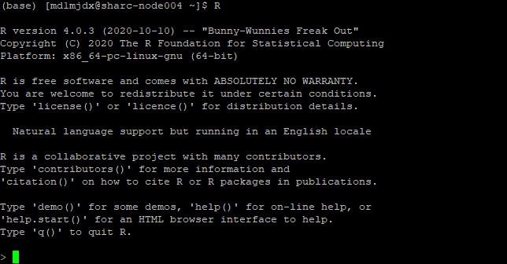

Fortunately, the analyses we will be performing in this module should run comfortably on a reasonably-modern laptop so we will be able to use a graphical interface.

When you open RStudio for first time it will display a “console” allowing you to enter R commands. The output from the command will be displayed directly underneath.

[figure not shown]

However, the main drawback of running R code in this manner is that it doesn’t automatically keep track of the steps you did. We could write the R code that we used in the file, and this is exactly what is supported in the form of an *R script*.

File -> New File -> R script

In the new file, type the text shown below. This introductory code will print a message to the screen.

```r
print("Hello World")
```

```
[1] "Hello World"
```

You will notice that pressing ENTER after typing the code just creates a new line in the script, rather than running the code. To *run* the code, we have to press CTRL and ENTER. The code that has been run, and the output, will be displayed in the console window. We will now demonstrate some basic arithmetic operations.

R can be used as a calculator to compute simple sums

```r
2 + 2
```

```
[1] 4
```

```r
2 - 2
```

```
[1] 0
```

```r
4 * 3
```

```
[1] 12
```

```r
10 / 2
```

```
[1] 5
```

The answer is displayed at the console with a `[1]` in front of it. The `1` inside the square brackets is a place-holder to signify how many values were in the answer (in this case only one). We will talk about dealing with lists of numbers shortly…

In the case of expressions involving multiple operations, R respects the [BODMAS](https://en.wikipedia.org/wiki/Order_of_operations#Mnemonics) system to decide the order in which operations should be performed.

```r
2 + 2 *3
```

```
[1] 8
```

```r
2 + (2 * 3)
```

```
[1] 8
```

```r
(2 + 2) * 3
```

```
[1] 12
```

R is capable of more complicated arithmetic such as trigonometry and logarithms; like you would find on a fancy scientific calculator. Of course, R also has a plethora of statistical operations as we will see.

```r
pi
```

```
[1] 3.141593
```

```r
sin (pi/2)
```

```
[1] 1
```

```r
cos(pi)
```

```
[1] -1
```

```r
tan(2)
```

```
[1] -2.18504
```

```r
log(1)
```

```
[1] 0
```

We can only go so far with performing simple calculations like this. Eventually we will need to store our results for later use. For this, we need to make use of *variables*.

## Variables

A variable is a letter or word which takes (or contains) a value. We use the assignment ‘operator’, `<-` to create a variable and store some value in it.

```r
x <- 10
x
```

```
[1] 10
```

```r
myNumber <- 25
myNumber
```

```
[1] 25
```

We also can perform arithmetic on variables using functions:

```r
sqrt(myNumber)
```

```
[1] 5
```

We can add variables together:

```r
x + myNumber
```

```
[1] 35
```

We can change the value of an existing variable:

```r
x <- 21
x
```

```
[1] 21
```

We can set one variable to equal the value of another variable:

```r
x <- myNumber
x
```

```
[1] 25
```

When we are feeling lazy we might give our variables short names (`x`, `y`, `i`…etc), but a better practice would be to give them meaningful names. There are some restrictions on creating variable names. They cannot start with a number or contain characters such as `.` and ‘-’. Naming variables the same as in-built functions in R, such as `c`, `T`, `mean` should also be avoided.

## Functions

**Functions** in R perform operations on **arguments** (the inputs(s) to the function). We have already used:

```r
sin(x)
```

```
[1] -0.1323518
```

this returns the sine of x. In this case the function has one argument: **x**. Arguments are always contained in parentheses – curved brackets, **()** – separated by commas.

Arguments can be named or unnamed, but if they are unnamed they must be ordered (we will see later how to find the right order). The names of the arguments are determined by the author of the function and can be found in the help page for the function. When testing code, it is easier and safer to name the arguments. `seq` is a function for generating a numeric sequence *from* and *to* particular numbers. Type `?seq` to get the help page for this function.

```r
seq(from = 3, to = 20, by = 4)
```

```
[1]  3  7 11 15 19
```

```r
seq(3, 20, 4)
```

```
[1]  3  7 11 15 19
```

Arguments can have *default* values, meaning we do not need to specify values for these in order to run the function.

`rnorm` is a function that will generate a series of values from a *normal distribution*. In order to use the function, the bare minimum amount of information required is how many values we want

```r
## this will produce a random set of numbers, so everyone will get a different set of numbers
## See wikipedia entry for normal distribution for how to generate example curves in R: https://commons.wikimedia.org/wiki/File:Normal_Distribution_PDF.svg

rnorm(n=10)
```

```
 [1] -0.8014775  1.1224732 -2.4199947  0.6962258 -0.5699338 -1.4114770 -0.5278896 -0.1263661  0.4048183 -1.5546008
```

The normal distribution is defined by a *mean* (average) and *standard deviation* (spread).

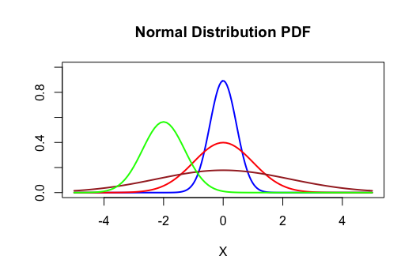

However, in the above example we didn’t tell R what mean and standard deviation we wanted. So how does R know what to do? All arguments to a function and their default values are listed in the help page

(*N.B sometimes help pages can describe more than one function*)

```r
?rnorm
```

In this case, we see that the defaults for mean and standard deviation are 0 and 1. We can change the function to generate values from a distribution with a different mean and standard deviation using the `mean` and `sd` *arguments*. It is important that we get the spelling of these arguments exactly right, otherwise R will an error message, or (worse?) do something unexpected.

```r
rnorm(n=10, mean=2,sd=3)
```

```
 [1]  1.3628537 12.1467645  4.2463023  0.2725479  3.4993785  2.7243135  3.7164681  5.3515808  0.3400504  5.9344215
```

```r
rnorm(10, 2, 3)
```

```
 [1]  0.61886728  1.21165720  4.85153007  0.03627055  6.69107447  7.99820770  3.70702919 -2.11298782  4.05936288
[10]  1.36572447
```

In the examples above, `seq` and `rnorm` were both outputting a series of numbers, which is called a *vector* in R and is the most-fundamental data-type.

Just as we can save single numbers as a variable, we can also save a vector. In fact a single number is still a vector.

```r
my_seq <- seq(from = 3, to = 20, by = 4)
```

The arithmetic operations we have seen can be applied to these vectors; exactly the same as a single number.

```r
my_seq + 2
```

[output not shown]

```r
my_seq * 2
```

[output not shown]

### Exercise

- What is the value of `pi` to 3 decimal places?
  - see the help for `round` `?round`
- How can we a create a sequence from 2 to 20 comprised of 5 equally-spaced numbers?
  - i.e. not specifying the `by` argument and getting R to work-out the intervals
  - check the help page for seq `?seq`
- Create a *variable* containing 1000 random numbers with a *mean* of 2 and a *standard deviation* of 3
  - what is the maximum and minimum of these numbers?
  - what is the average?
  - HINT: see the help pages for functions `min`, `max` and `mean`

## Saving your work

If you want to re-visit your code at any point, you will need to save a copy.

**File > Save >**

## Packages in R

So far we have used functions that are available with the *base* distribution of R; the functions you get with a clean install of R. The open-source nature of R encourages others to write their own functions for their particular data-type or analyses.

Packages are distributed through *repositories*. The most-common ones are CRAN and Bioconductor. CRAN alone has many thousands of packages.

- The [meta cran](https://www.r-pkg.org/) website can be used to browse packages available in CRAN
- Bioconductor packages can be browsed [here](http://bioconductor.org/packages/release/BiocViews.html#___Software)

CRAN and Bioconductor have some level of curation so should be the first place to look. Researchers sometimes make their packages available on github. However, there is no straightforward way of searching github for a particular package and no guarentee of quality.

The **Packages** tab in the bottom-right panel of RStudio lists all packages that you currently have installed. Clicking on a package name will show a list of functions that available once that package has been loaded.

There are functions for installing packages within R. If your package is part of the main **CRAN** repository, you can use `install.packages`.

We will be using a set of `tidyverse` R packages in this practical. To install them, we would do.

```r
install.packages("readr")
install.packages("ggplot2")
install.packages("dplyr")
# to install the entire set of tidyverse packages, we can do install.packages("tidyverse"). But this will take some time
```

A package may have several *dependencies*; other R packages from which it uses functions or data types (re-using code from other packages is strongly-encouraged). If this is the case, the other R packages will be located and installed too.

**So long as you stick with the same version of R, you won’t need to repeat this install process.**

Once a package is installed, the `library` function is used to load a package and make it’s functions / data available in your current R session. *You need to do this every time you load a new RStudio session*. Let’s go ahead and load the `readr` so we can import some data.

```r
## readr is a packages to import spreadsheets into R
library(readr)
```

# Dealing with data

The [*tidyverse*](https://www.tidyverse.org/) is an eco-system of packages that provides a consistent, intuitive system for data manipulation and visualisation in R.

We are going to explore some of the basic features of the `tidyverse` using data from the [gapminder](https://www.gapminder.org/data/) project, which have been bundled into an [R package](https://github.com/jennybc/gapminder). These data give various indicator variables for different countries around the world (life expectancy, population and Gross Domestic Product). We have saved these data as a `.csv` file called `gapminder.csv` in a sub-directory called `raw_data/` to demonstrate how to import data into R.

## Uploading the data

If you haven’t done so already, you will need to *upload* some data to the Rstudio workbench before we can analyse it. There is an upload option in the bottom-right panel.

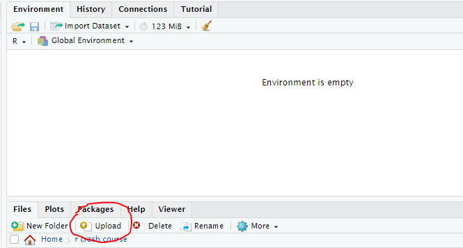

Click the upload button and select the zip file that you downloaded from the course homepage. *You do not need to extract the file on your own computer first*.

- r_crash_course.zip

## Reading in data

Any `.csv` file can be imported into R by supplying the path to the file to `readr` function `read_csv` and assigning it to a new object to store the result. A useful sanity check is the `file.exists` function which will print `TRUE` is the file can be found in the working directory.

```r
gapminder_path <- "raw_data/gapminder.csv"
file.exists(gapminder_path)
```

```
[1] TRUE
```

Assuming the file can be found, we can use `read_csv` to import. Other functions can be used to read tab-delimited files (`read_delim`) or a generic `read.table` function. A data frame object is created.

```r
library(readr)
gapminder_path <- "raw_data/gapminder.csv"
gapminder <- read_csv(gapminder_path)
```

**Why would specifying `gapminder_path` as** `Users/Anna/Documents/workflows/workshops/r-crash-course/raw_data/gapminder.csv` **be a bad idea?** Would you be able to re-run the analysis on another machine?

The data frame object in R allows us to work with **“tabular” data**, like we might be used to dealing with in Excel, where our data can be thought of having **rows and columns**. The values in **each column** have to all be of the **same type** (i.e. all numbers or all text).

In Rstudio, you can **view the contents of the data frame** we have just created using function `View()`. This is useful for interactive exploration of the data, but not so useful for automation, scripting and analyses.

```r
## Make sure that you use a capital letter V

View(gapminder)
```

| country | continent | year | lifeExp | pop | gdpPercap |
| --- | --- | --- | --- | --- | --- |
| Afghanistan | Asia | 1952 | 28.80100 | 8425333 | 779.4453 |
| Afghanistan | Asia | 1957 | 30.33200 | 9240934 | 820.8530 |
| Afghanistan | Asia | 1962 | 31.99700 | 10267083 | 853.1007 |
| Afghanistan | Asia | 1967 | 34.02000 | 11537966 | 836.1971 |
| Afghanistan | Asia | 1972 | 36.08800 | 13079460 | 739.9811 |
| Afghanistan | Asia | 1977 | 38.43800 | 14880372 | 786.1134 |
| Afghanistan | Asia | 1982 | 39.85400 | 12881816 | 978.0114 |
| Afghanistan | Asia | 1987 | 40.82200 | 13867957 | 852.3959 |
| Afghanistan | Asia | 1992 | 41.67400 | 16317921 | 649.3414 |
| Afghanistan | Asia | 1997 | 41.76300 | 22227415 | 635.3414 |

[output cut: 990 more lines]

We should **always check the data frame that we have created**. Sometimes R will happily read data using an inappropriate function and create an object without raising an error. However, the data might be unusable. Consider:-

```r
test <- read_table(gapminder_path)
```

```
Warning: 324 parsing failures.
row col  expected    actual                     file
145  -- 1 columns 3 columns 'raw_data/gapminder.csv'
146  -- 1 columns 3 columns 'raw_data/gapminder.csv'
147  -- 1 columns 3 columns 'raw_data/gapminder.csv'
148  -- 1 columns 3 columns 'raw_data/gapminder.csv'
149  -- 1 columns 3 columns 'raw_data/gapminder.csv'
... ... ......... ......... ........................
See problems(...) for more details.
```

```r
View(test)
```

| "country","continent","year","lifeExp","pop","gdpPercap" |
| --- |
| "Afghanistan","Asia",1952,28.801,8425333,779.4453145 |
| "Afghanistan","Asia",1957,30.332,9240934,820.8530296 |
| "Afghanistan","Asia",1962,31.997,10267083,853.10071 |
| "Afghanistan","Asia",1967,34.02,11537966,836.1971382 |
| "Afghanistan","Asia",1972,36.088,13079460,739.9811058 |
| "Afghanistan","Asia",1977,38.438,14880372,786.11336 |
| "Afghanistan","Asia",1982,39.854,12881816,978.0114388 |
| "Afghanistan","Asia",1987,40.822,13867957,852.3959448 |
| "Afghanistan","Asia",1992,41.674,16317921,649.3413952 |
| "Afghanistan","Asia",1997,41.763,22227415,635.341351 |

[output cut: 990 more lines]

Quick sanity checks can also be performed by inspecting details in the environment tab. A useful check in RStudio is to use the `head` function, which prints the first 6 rows of the data frame to the screen.

```r
head(gapminder)
```

| country | continent | year | lifeExp | pop | gdpPercap |
| --- | --- | --- | --- | --- | --- |
| Afghanistan | Asia | 1952 | 28.801 | 8425333 | 779.4453 |
| Afghanistan | Asia | 1957 | 30.332 | 9240934 | 820.8530 |
| Afghanistan | Asia | 1962 | 31.997 | 10267083 | 853.1007 |
| Afghanistan | Asia | 1967 | 34.020 | 11537966 | 836.1971 |
| Afghanistan | Asia | 1972 | 36.088 | 13079460 | 739.9811 |
| Afghanistan | Asia | 1977 | 38.438 | 14880372 | 786.1134 |

We have used a nice, clean, dataset as our example for the workshop. Other datasets out in the wild might not be so ameanable for analysis in R. If your data look like this, you might have problems:-

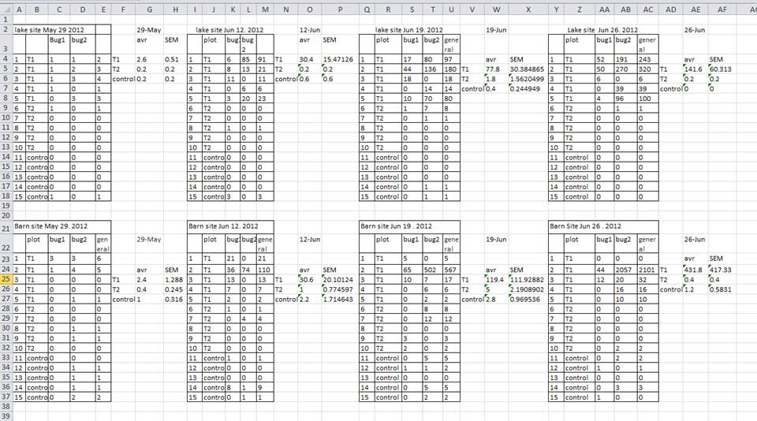

We recommend the Data Carpentry materials on spreadsheet organisation for an overview of common pitfalls - and how to address them

- https://datacarpentry.org/spreadsheet-ecology-lesson/

N.B. The datasets you will be using for the assessment should also be ready for analysis.

# From scripts to reproducible reports

You will notice that contents of the `gapminder` data frame (either the whole table or first six rows using `head`) get displayed at the console. What happens if we run code to produce a plot? Add the following line of code to your R script. It will produce a scatter plot of the in-built `cars` dataset. We will explore plotting in much more detail, and R is capable of much nicer-looking plots. It is just an example for now.

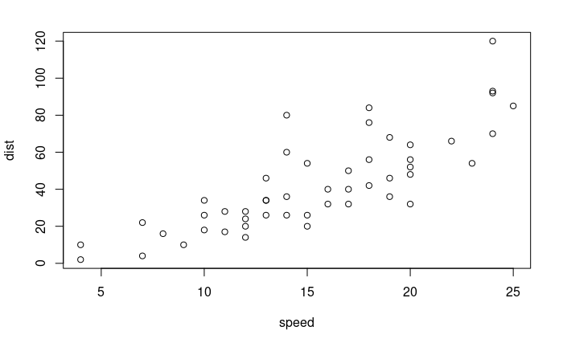

```r
plot(cars)
```

The plot gets displayed in it’s own panel in the bottom-right panel. If we wanted to include this plot in any kind of scientific output (presentation, report, thesis etc) we would have to export plot and paste it manually into the report. Similarly, we would have to copy any paste and output tables. **Clearly, we should try and avoid these manual steps as much as possible**. The youtube video linked below illustrates these points if you still convincing.

- [A non-reproducible workflow](https://www.youtube.com/embed/s3JldKoA0zw)

From now on, We’ll be working in an [**R markdown**](https://bookdown.org/yihui/rmarkdown/) file. This document type allows us to **combine R code with** markdown, **a documentation language**, providing a framework for [literate programming](https://en.wikipedia.org/wiki/Literate_programming). In an R markdown, R code chunks can be executed independently and interactively, with output visible immediately beneath the input.

The submission of the final assessment for the module will consist of an R markdown file, and the Word document that is generated from it. **It should be possible for the assessment marker to produce exactly the same document given the same dataset and your notebook.**

## Anatomy of an R markdown file

A new markdown file can be created using the menus. You can choose a title for the report and your name.

**File -> New File -> R markdown**

A new pane should open that contains an example markdown file.

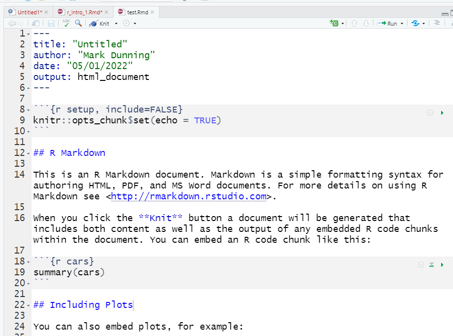

We will breakdown the contents of the file.

- Lines 1 to 6. The *header* information for the file. These define the title, author and date. **DO not delete the `----` appearing on lines 1 and 6
- Lines 8 to 10. Some code that defines how the R code contained within the file is executed and displayed in the final report. Don’t worry about this for now
- Line 12. A formatting line to display a sub-heading in the report
- Lines 14 to 17. Text to be displayed in the report
- Lines 18 to 20. The first example of an **R Code Chunk**. The actual to be run is given be line 19 (`summary(cars)`) and lines 18 and 20 are used to tell RStudio where the code ends and begins.

The code chunk from lines 18 to 20 can be run be clicking on line 19 and pressing CTRL + ENTER; in much the same way as we ran code from an R script. However, the difference this time is that the output gets displayed directly underneath the code chunk.

```r
summary(cars)
```

```
     speed           dist
 Min.   : 4.0   Min.   :  2.00
 1st Qu.:12.0   1st Qu.: 26.00
 Median :15.0   Median : 36.00
 Mean   :15.4   Mean   : 42.98
 3rd Qu.:19.0   3rd Qu.: 56.00
 Max.   :25.0   Max.   :120.00
```

Do not press CTRL and ENTER when the cursor is on line 18 or 20. This will result in the error message `Error: attempt to use zero-length variable name`. Alternatively, the green run button (triangle) on the right-hand side can be used to run execute the code inside the chunk.

A bit further down, there is another code chunk for creating a plot. It is the same code that we saw previously. Again, the plot will be displayed directly underneath.

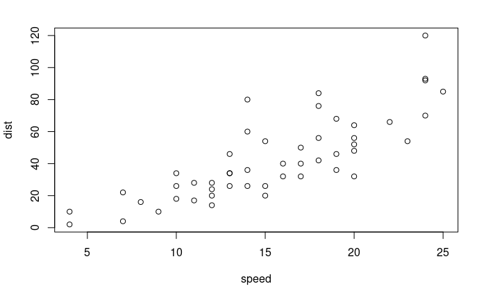

```r
plot(cars)
```

Before generating a report you will need to save the file with the menu **File -> Save**. A Word or HTML document can be created by selecting **Knit to Word** or **Knit to HTML** from the Drop-down menu next to Preview. N.B. you may be prompted to install extra software before doing this. It is also possible to create PDF documents, but you will need to install extra software on your laptop.

When the *Knit* option is selected, RStudio will run all the code contained in your markdown file, in order (top to bottom), and create a report in the requested format (provided there are no errors).

## More about code chunks

New code chunks can be inserted using the insert chunk menu.

Always create a new code chunk using the menu option. If you create one manually, you are likely to make a mistake. Formatting problems when creating a code chunk are likely to result in RStudio not being able to run your code.

**Do not delete the first and last lines of the code chunk that begin with the backtick symbols “``{r } and "`”** These are used by RStudio to identify where R code begins and ends. Errors in these lines are likely to results in errors running your code. The background colour used in RStudio should be white for plaintext, and grey for code.

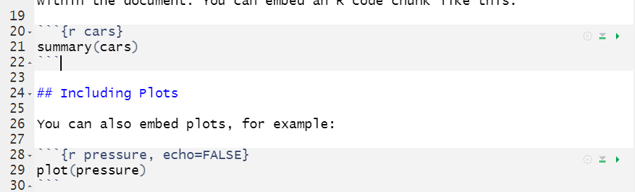

If the end lines of a code chunk are incomplete or incorrect, RStudio will be unable to recognise where the code ends. See an example below where the end of the code chunk has only two “`” symbols.

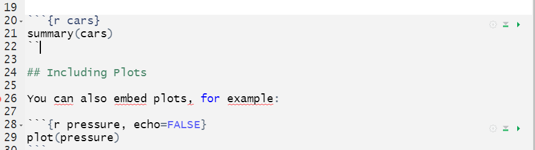

Notice that the light grey background extends beyond line 22 (where the R code should end). RStudio now thinks that Line 24 is a comment and that line 26 is intended to be R code rather than text. The background colour for Line 26 should be white (as for the valid chunk above),

A code chunk can contain multiple lines of code; with each now line added by pressing ENTER. Just make sure to keep within the grey background when writing the code.

However, it is advisable to keep the code chunks concise. Having all the code for your analysis within the same chunk would make the report difficult to read, and also to *debug* (fix errors). Try to use a code chunk to describe a single step in the analysis process (e.g. generating a figure or table), and use the space between code chunks to interpret the results or introduce the next analysis step.

Code comments can be employed when you want to make notes to your future self to explain your code; but the comments may not be relevant to person reading the final report. The hash symbols inside a code chunk can be used to start a comment;`##`. Any text following the `#` is ignored by RStudio.

```r
### the summary function produces numerical summaries from a data frame
### it displays a table with each column comprising the quantiles and average of a given column
### for more help see ?summary

summary(cars)
```

```
     speed           dist
 Min.   : 4.0   Min.   :  2.00
 1st Qu.:12.0   1st Qu.: 26.00
 Median :15.0   Median : 36.00
 Mean   :15.4   Mean   : 42.98
 3rd Qu.:19.0   3rd Qu.: 56.00
 Max.   :25.0   Max.   :120.00
```

## Chunk options

These and other chunk options are described in R markdown cheatsheet available through the Help menu in RStudio.

There are many options available to adjust the formating of your markdown file. See the Markdown Quick Reference guide that can be accessed from the RStudio Help menu

## Exporting files from R workbench

Since we are working on a remote machine (rather than our own laptop), all the files that we create will also be stored on this remote machine. If we want to view the markdown documents and reports that we create we will need to *export* them. This can be done using the **export** option from the More menu in the bottom-right panel.

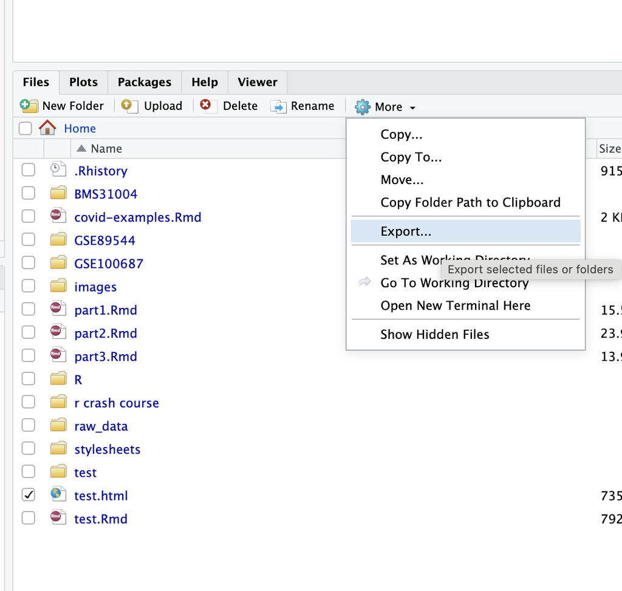

**Exercise**:

- Make sure you can create a new notebook and “Knit” to a Word document
  - **For the assessment you will need to be able to create Word documents from within RStudio, so please ask if you have any problems**
- Create a new R markdown file using the instructions above and create a code chunk to read the `gapminder.csv` into R and print the first few rows of the resulting data frame. (e.g. using the `head` function)
- Export the markdown file and word document you have created to your own computer